# Multivariable regression of microbiome and IBD using MaAsLin2 R package

David Xin Zhao

Last edited 16 November 2022

## MaAsLin2

[MaAsLin2](https://github.com/biobakery/biobakery/wiki/maaslin2) is to efficiently determine multivariable association between phenotypes, environments, exposures, covariates and microbial meta-omics features.

## Install MaAsLin2 with Bioconductor

```r
# if(!requireNamespace("BiocManager", quietly = TRUE))
#     install.packages("BiocManager")
# BiocManager::install("Maaslin2")

library(Maaslin2)
library(tidyverse)
```

## Multiple regression of microbiome and clincial covariates of interest

### Load data sets (use example datasets provided by MaAsLin2 package)

```r
# microbiome abundance data
df_input_data <- read.table(file = input_data,
                            header = TRUE,
                            sep = "\t",
                            row.names = 1,
                            stringsAsFactors = FALSE)

# meta data
df_input_metadata <- read.table(file=input_metadata,
                                header = T,
                                sep="\t",
                                row.names = 1,
                                stringsAsFactors = F)

# pathway data
df_input_path <- data.frame(read.csv("./pathabundance_relab.tsv",
                                     sep = "\t",
                                     stringsAsFactors = F,
                                     row.names = 1))
```

### Fit mutiple linear regression model on microbiome data

The following command runs MaAsLin2 on the HMP2 data, running a multivariable regression model to test for the association between microbial species abundance versus IBD diagnosis and dysbiosis scores.

```r
fit_data2 <- Maaslin2(
        input_data = df_input_data,
        input_metadata = df_input_metadata,
        min_prevalence = 0, #without additional filtering
        normalization = "NONE",  #without additional normalization
        output = "demo_output2",
        fixed_effects = c("diagnosis", "dysbiosis"),  #set diagnosis and dysbiosis as fixed effect variables
        reference = c("diagnosis,nonIBD")) #set baseline for the categorical variable, diagnosis
## Warning in xtfrm.data.frame(x): cannot xtfrm data frames
```

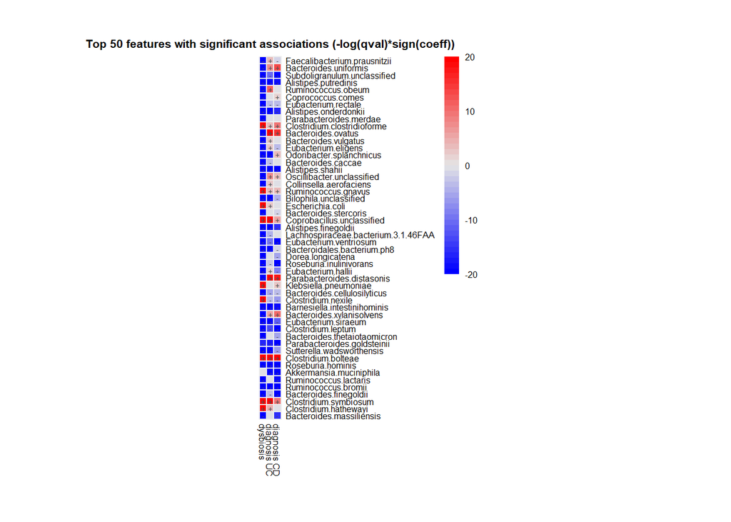

```r
all_results <- fit_data2$results #extract coefficients and q-value
```

### Evaluate significant genus based on model parameters

significant associations is provided in ‘significant_results.tsv’

```r
sig_results <- all_results %>%
        filter(qval <= 0.05) %>% #sig threshold
        arrange(qval)

head(sig_results, 5) #view first rows
```

```
##                        feature  metadata     value      coef     stderr
## 1 Faecalibacterium.prausnitzii dysbiosis dysbiosis -2.647940 0.07465408
## 2        Bacteroides.uniformis dysbiosis dysbiosis -3.503693 0.11995326
## 3 Subdoligranulum.unclassified dysbiosis dysbiosis -1.525402 0.06188741
## 4         Alistipes.putredinis dysbiosis dysbiosis -3.444523 0.14190247
## 5           Ruminococcus.obeum dysbiosis dysbiosis -1.946980 0.08362614
##            pval      name          qval    N N.not.zero
## 1 1.544980e-203 dysbiosis 4.032398e-201 1595       1534
## 2 1.589498e-150 dysbiosis 2.074294e-148 1595       1391
## 3 6.962634e-114 dysbiosis 6.057492e-112 1595       1546
## 4 5.443288e-111 dysbiosis 3.551745e-109 1595        940
## 5 2.023721e-103 dysbiosis 1.056382e-101 1595       1346
```

### Fit multivariable regression models on functional data

Authors tend to work with CPM units because we find them to be more convenient, but they are numerically equivalent to relative abundances for modeling purposes (CPM = RA * 1e6)

Quick tips for using MaAsLin2 on functional profiles: 1.To reduce the number of features, you typically want to run either the unstratified functional features ( or a filtered subset of the stratified features) 2.You may also want to remove functional features that are highly correlated to one specific taxon (i.e. likely contributed by that microbe), since these can be better-explained by taxonomic changes

```r
#This can also be done with with the HUMAnN 3 untiliy `humann_split_stratified_table`
unstrat_pathways <-function(dat_path){
  temp = dat_path[!grepl("\\|",rownames(dat_path)),]
  return(temp)
}

df_input_path = unstrat_pathways(df_input_path)
```

Run the same model as above on the MetaCyc pathway table generated from the bioBakery workflows.

```r
# fit the model on pathway (functional) data - it takes a few minutes
fit_func <- Maaslin2(
        input_data = df_input_path,
        input_metadata = df_input_metadata,
        output = "demo_functional",
        fixed_effects = c("diagnosis", "dysbiosis"),
        reference=c("diagnosis,nonIBD"),
        min_abundance = 0.0001,
        min_prevalence = 0.1)
## Warning in xtfrm.data.frame(x): cannot xtfrm data frames
```

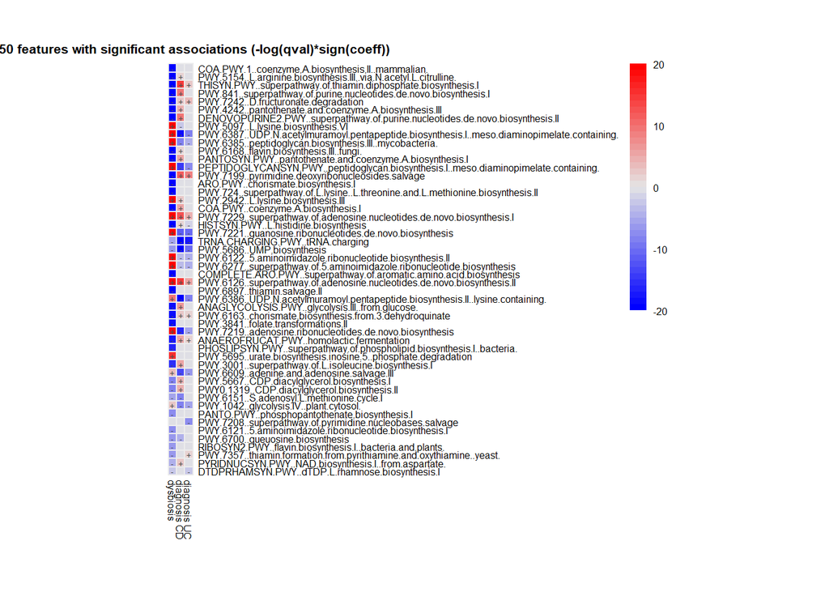

```r
# note: here we have the samples in the columns and the features in the rows and MaAsLin2 correctly identified this and was able to match the samples.

all_results_func <- fit_func$results
```

### Interactions

Unfortunately, MaAsLin2 does not yet provide a direct interface for testing for interaction. Instead, the user needs to create artificial interaction columns as additional ‘fixed_effects’ terms.

Using the above fit as an example, to test for the interaction between ‘diagnosis’ and ‘dysbiosis’, I can create two additional columns: ‘CD_dysbiosis’ and ‘UC_dysbiosis’ (since the reference for ‘diagnosis’ is ‘nonIBD’):

```r
df_input_metadata$CD_dysbiosis <- (df_input_metadata$diagnosis == "CD") * df_input_metadata$dysbiosis

df_input_metadata$UC_dysbiosis <- (df_input_metadata$diagnosis == "UC") * df_input_metadata$dysbiosis

fit_data_interaction <- Maaslin2(
        input_data = df_input_data,
        input_metadata = df_input_metadata,
        min_prevalence = 0,
        normalization = "NONE",
        output = "demo_output_interaction",
        fixed_effects = c("diagnosis", "dysbiosis", "CD_dysbiosis", "UC_dysbiosis"),
        reference = c("diagnosis,nonIBD"))
## Warning in xtfrm.data.frame(x): cannot xtfrm data frames
```

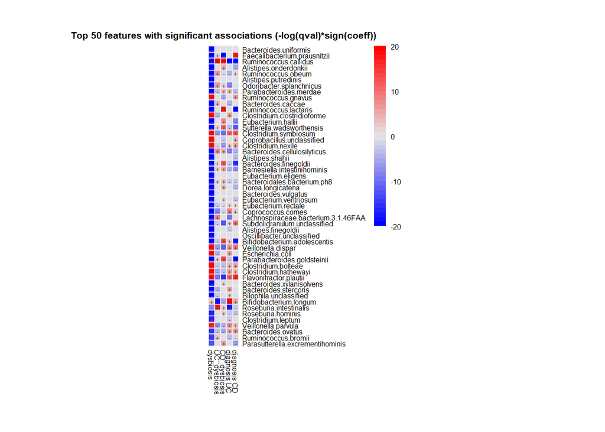

```r
all_results_interaction <- fit_data_interaction$results  # store results
```

### Random effects

We note that HMP2 is a longitudinal design where the same subject (column ‘subject’) can have multiple samples. We thus ask MaAsLin2 to use subject as its random effect grouping variable:

```r
fit_data_random <- Maaslin2(
        input_data = df_input_data,
        input_metadata = df_input_metadata,
        min_prevalence = 0,
        normalization = "NONE",
        output = "demo_output_random",
        fixed_effects = c("diagnosis", "dysbiosis"),
        random_effects = c("subject"),
        reference = c("diagnosis,nonIBD")
)
## Warning in xtfrm.data.frame(x): cannot xtfrm data frames
```

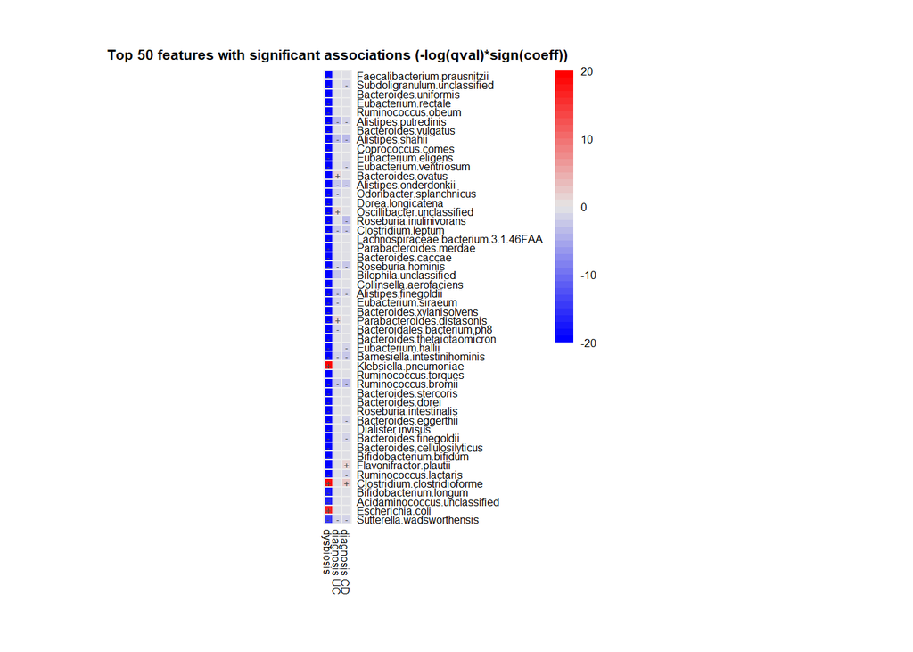

```r
all_results_random <- fit_data_random$results
```

If you are interested in testing the effect of time in a longitudinal study, then the itme point variable should be included in ‘fixed_effects’ during your MaAsLin2 call.

### Prevalence and abundance filtering in MaAsLin2

minimum prevalence threshold: 10-50% (up to 70-90% can be reasonable) minimum relative abundance threshold: 0.0001

```r
fit_data_filter = Maaslin2(
    input_data = df_input_data,
    input_metadata = df_input_metadata,
    normalization = "NONE",
    output = "demo_output_filter",
    fixed_effects = c("diagnosis", "dysbiosis"),
    reference = c("diagnosis,nonIBD"),
    random_effects = c("subject"),
    min_prevalence = 0.1,
    min_abundance = 0.0001)
## Warning in xtfrm.data.frame(x): cannot xtfrm data frames
```

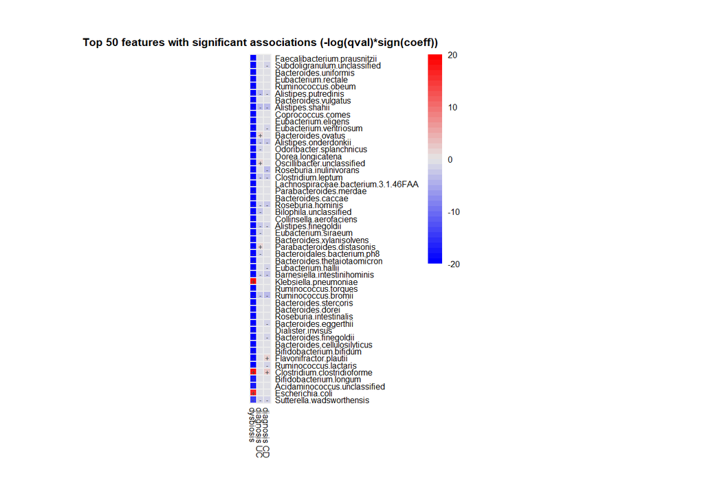